# MP4

Nate Mange, Joseph Locurto, Samantha Sweeney, Tingwei Hu

2023-04-12

# Introduction

MP4 delves into the effects of wing shape on flow patterns with foils moving in a fluid. We aimed to predict bird flight behavior by examining the lift and drag components. We used CAD software and 3D printing technology to create two biomimetic wings for the puffin and the swift that reflect their wing morphologies. Flow patterns were analyzed through particle tracking. We strove to establish the flight characteristics that the wings impart to our birds based on lift, drag, and flow pattern data.

# Methods

We 3D printed wings of *Apus apus* (common swift) and *Fratercula arctica* (Atlantic puffin), specifying the shape on the chord and span dimensions of the wing but not the depth. Wings were attached to a 3D printed bird body and placed in a custom swim tunnel at an angle of attack of 15 degrees with water traveling across at 0.1m/s. We measured the amount of lift and drag generated by the wing by attaching the wing-bird model to force transducers on the forward-backwards and up-down axes in relation to the orientation of the model. To qualitatively assess flow, we visualized velocity vectors in FIJI using procedures provided on course website.

We calculated the lift and drag coefficients and aspect ratio (AR) using methods provided on project website. We fitted a linear model using lift to drag ratio as the dependent variable and aspect ratio as the independent variable using availabe class data at time of analysis.

# Results

Parameters of the puffin and swift wings obtained from our calculations are shown in Table 1. Our linear model did not find the lift to drag ratio predictable by AR ($\beta$ = 0.809, *p* = 0.389).

**Table 1: $C_L$, $C_D$, and lift to drag ratio of wings used.**

| species | CL | CD | lift2drag.ratio |
| --- | --- | --- | --- |
| Puffin | 11640.00 | 1169.853 | 9.949969 |
| Swift | 5225.94 | 1039.107 | 5.029260 |

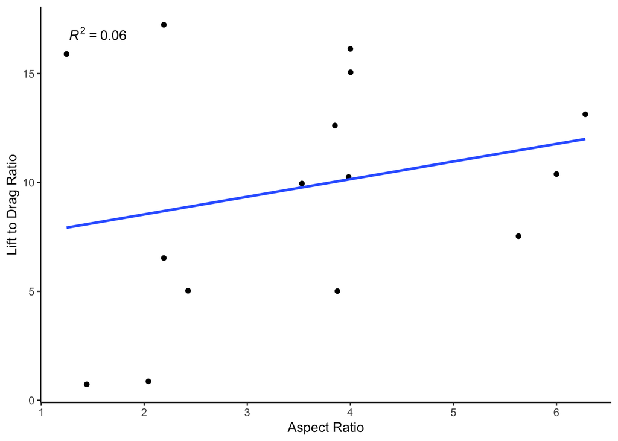

**Figure 1:** Correlation between lift to drag ratio and AR.

```r
class_dat <- read_csv('classdata.csv')

class_dat <- class_dat %>%
  drop_na() %>%
  rename('l2d' = 'Cl/Cd')

class_dat %>%
  ggplot(aes(AR,l2d))+geom_point()+geom_smooth(method=lm,se=FALSE)+
  stat_poly_eq()+
  theme(axis.line = element_line(colour = "black"),
    panel.grid.major = element_blank(),
    panel.grid.minor = element_blank(),
    panel.border = element_blank(),
    panel.background = element_blank())+
  ylab('Lift to Drag Ratio')+
  xlab('Aspect Ratio')
```

```r
lm1 <- lm(l2d ~ AR, class_dat)

summary(lm1)
```

```
##
## Call:
## lm(formula = l2d ~ AR, data = class_dat)
##
## Residuals:
##     Min      1Q  Median      3Q     Max
## -7.7015 -3.8922  0.1128  3.7426  8.5547
##
## Coefficients:
##             Estimate Std. Error t value Pr(>|t|)
## (Intercept)   6.9153     3.4781   1.988   0.0683 .
## AR            0.8089     0.9070   0.892   0.3887
## ---
## Signif. codes:  0 '***' 0.001 '**' 0.01 '*' 0.05 '.' 0.1 ' ' 1
##
## Residual standard error: 5.408 on 13 degrees of freedom
## Multiple R-squared:  0.05766,    Adjusted R-squared:  -0.01483
## F-statistic: 0.7955 on 1 and 13 DF,  p-value: 0.3887
```

```r
confint(lm1)
```

```
##                  2.5 %    97.5 %
## (Intercept) -0.5986225 14.429195
## AR          -1.1504751  2.768294
```

# Discussion

## Question 3

Soaring easily enables birds to cover long distances with minimal energy expenditure - though it does come with tradeoffs. Soaring birds typically have larger wingspans and heavier bodies than non-soaring birds. This makes them less agile and more vulnerable to predators. Soaring birds typically require strong thermal currents to maintain altitude, limiting their range. Thermal currents are rising columns of warm air that are formed by the sun heating the ground. When the surface air becomes warmer than the surrounding air, it rises and creates a thermal current. Soaring birds use these currents to gain and maintain altitude without flapping their wings (Leshem and Yom-Tov (1996)). These currents are more common in areas where the surface air heats up quickly, such as deserts. Birds that cannot soar easily tend to be more agile and can fly in a wider range of environments such as coastal areas and forests.

## Question 4

Bird bodies have many adaptations that optimize lift resulting from the wing. Birds typically have long, narrow wings with a curved, streamlined body shape. A bird’s flat or slightly curved wings help generate lift by creating differences in pressure above and below the wing (high pressure below, low pressure above). The presence of feathers creates a smooth surface over which air can flow - furthering the body’s streamlined shape. More specifically, slotted tips at the end of a birds’ wings can work to reduce drag by acting as winglets, or smaller wings attached to the tips of a base wing (Tucker (1993)). This helps reduce drag and increase efficiency. Lastly, a bird’s hollow bones decrease its weight, making it easier for them to take off and fly.

## Question 5

We did not find correlation between AR and lift to drag ratio, contrary to our expectation of a positive correlation and as reported by Bataillé et al. (2007), who found that a higher AR would lead to a higher lift-to-drag ratio but would decrease the maximum lift coefficient. It could be that our AR spanned a wide range to the point where the reduction in maximum lift coefficient had an effect on our lift to drag ratio.

## Question 6

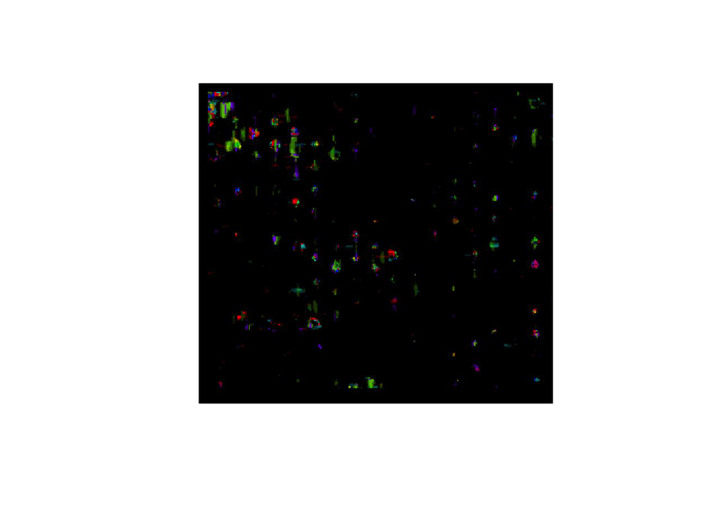

**Figure 2:** Puffin wings vortices analysis.

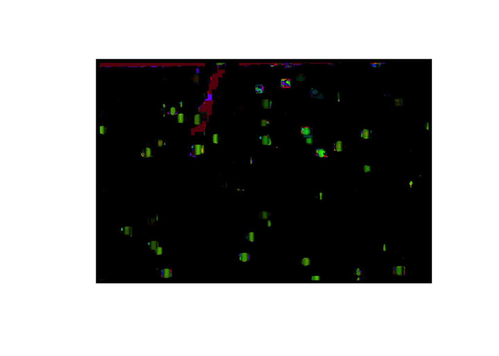

**Figure 3:** Swift wing vortices analysis.

```r
plot_jpeg('Swift_OF.jpg')
```

# Author Contributions

All authors contributed equally to the project.

# References

Bataillé, Boris, Damien Poinsot, Chinnapat Thipyopas, and Jean-Marc Moschetta. 2007. “Fixed-Wing Micro Air Vehicles with Hovering Capabilities.” ECOLE NATIONALE SUPERIEURE DE L’AERONAUTIQUE ET DE L’ESPACE TOULOUSE (FRANCE).

Leshem, Yossi, and Yoram Yom-Tov. 1996. “The Use of Thermals by Soaring Migrants.” *Ibis* 138 (4): 667–74.

Tucker, Vance A. 1993. “Gliding Birds: Reduction of Induced Drag by Wing Tip Slots Between the Primary Feathers.” *Journal of Experimental Biology* 180 (1): 285–310.